# Modelling the distribution of biodiversity under global climate change

Jorge Assis, PhD // Nord University, Norway // biodiversityDS, Centre of Marine Sciences, Portugal

## Species Distribution Modelling

## Model fitting

biodiversityDS .

Model fitting (i.e., the **relationship between species occurrence and environmental predictors**) is the core of SDM.

### Presence / absence data

```r
# load libraries
library(terra)
library(tidyterra)
library(ggplot2)
library(bDSSDMTools)
# load a vector defining global landmasses
landmass <- vect("../Data/Vector data/Landmass/landmass.shp")
# read occurrence records (presences and absences)
records <- read.table("../Data/Text delimited/species_presence_absence_records.csv", sep = ";",
    header = TRUE)
# transform data.frame into a spatial object
records <- vect(records, geom = c("Lon", "Lat"), crs = "EPSG:4326")
```

S5 // Developing Species Distribution Models in R

biodiversityDS .

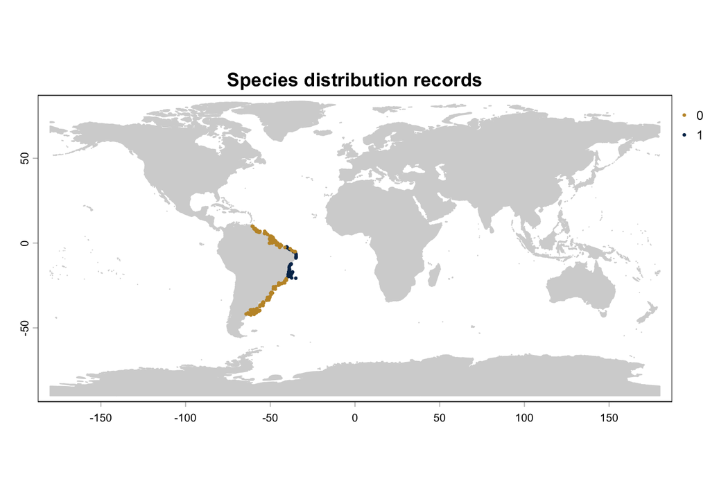

```r
# plot records
plot(landmass, main = "Species distribution records", col = "#D4D4D4", border = "#D4D4D4", axes = TRUE)
plot(records, y = "PA", col = c("#c29431", "#043259"), pch = 16, cex = 0.5, add = TRUE)
```

S5 // Developing Species Distribution Models in R

biodiversityDS .

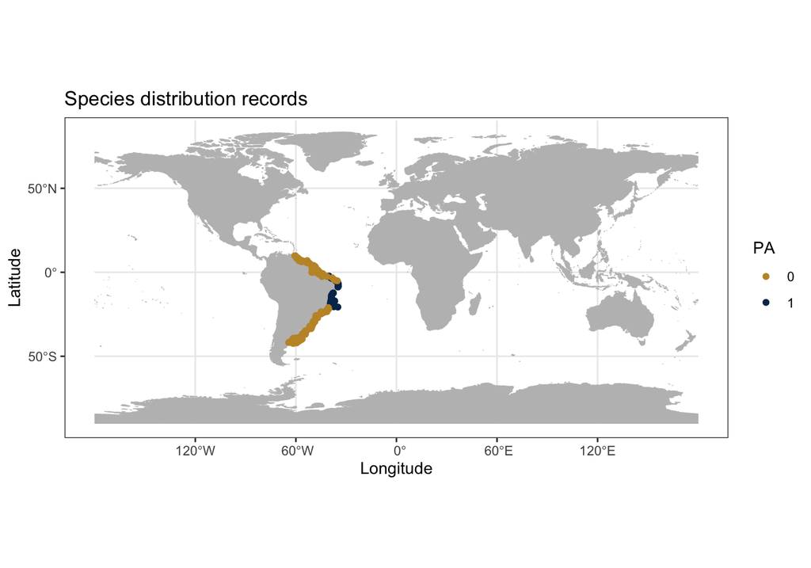

```r
# plot records
ggplot() + geom_spatvector(data = landmass, fill = "gray", color = "gray") + geom_spatvector(data = records,
    aes(color = as.factor(PA)), size = 1.5) + scale_color_manual(values = c("#c29431", "#043259"),
    name = "PA") + labs(title = "Species distribution records") + xlab("Longitude") + ylab("Latitude") +
    theme_bw()
```

S5 // Developing Species Distribution Models in R

biodiversityDS .

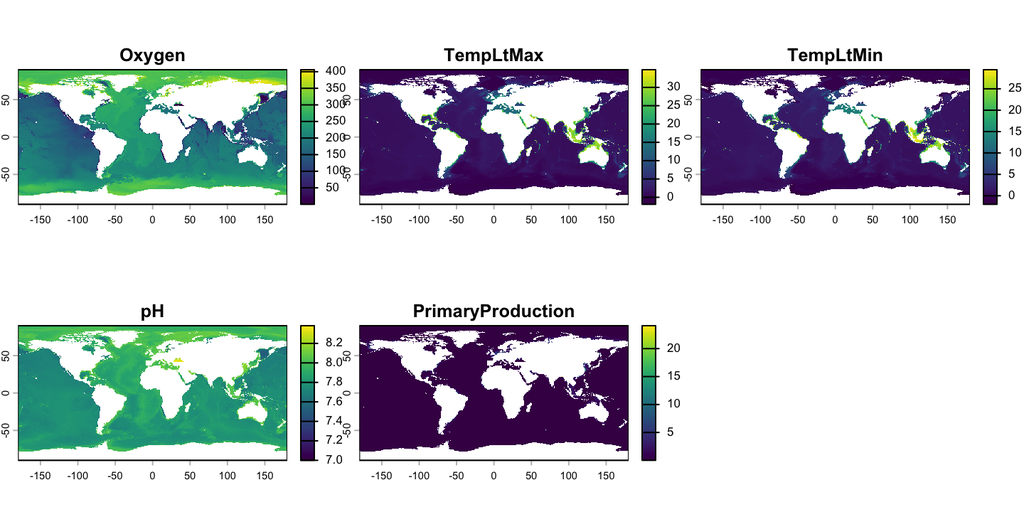

```r
# import environmental data
files <- c("../Data/Raster data/Present Benthic DissolvedMolecularOxygen Mean.tif", "../Data/Raster data/Present Benthic OceanTemperature LtMax.tif",
    "../Data/Raster data/Present Benthic OceanTemperature LtMin.tif", "../Data/Raster data/Present Benthic pH Mean.tif",
    "../Data/Raster data/Present Benthic TotalPrimaryProductionPhyto Mean.tif")
# produce and plot raster layers
environmentalLayers <- rast(files)
# change for friendly names
names(environmentalLayers) <- c("Oxygen", "TempLtMax", "TempLtMin", "pH", "PrimaryProduction")
plot(environmentalLayers)
```

S5 // Developing Species Distribution Models in R

biodiversityDS .

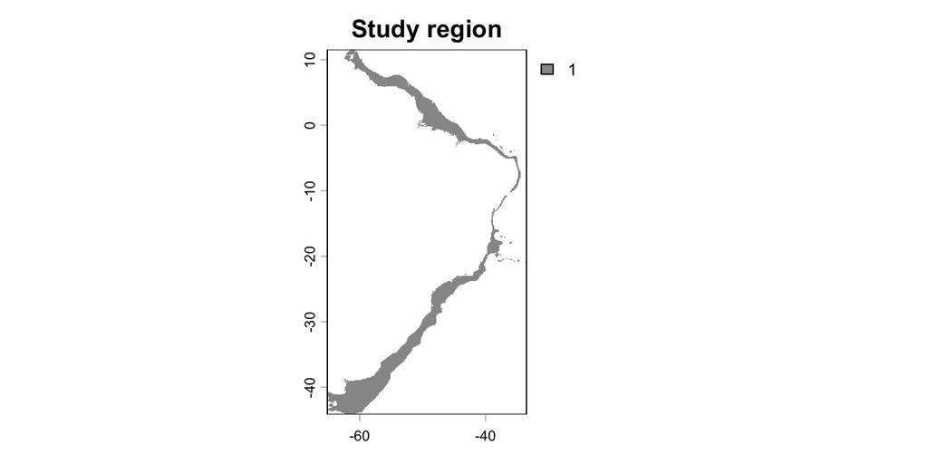

```r
# develop a study region layer
myStudyRegion <- studyRegion(rasterLayers=environmentalLayers, # SpatRaster of layers
                             presences=records, # presence records
                             distanceThreshold=200000, # distance from records in meters
                             topographyLayer = "../Data/Raster data/Bathymetry.tif", # bathymetry layer
                             verticalPref=c(0,-500), # known vertical distribution
                             coastalLayer = "../Data/Raster data/CoastLine.tif" ) # consider intertidal region
# inspect the study region layer
plot(myStudyRegion, main="Study region", col="#979797", axes=TRUE)
```

S5 // Developing Species Distribution Models in R

biodiversityDS .

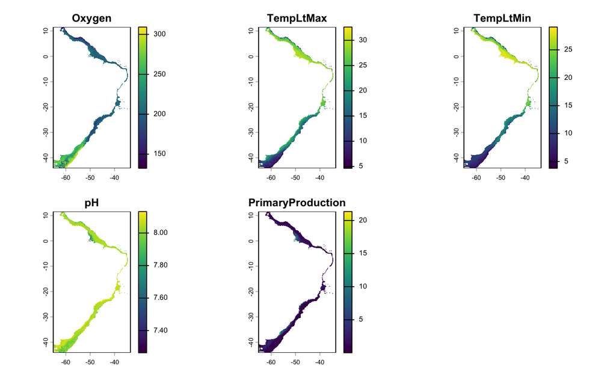

```r
# crop the environmental layers to the extent of the study region
environmentalLayers <- crop(environmentalLayers, myStudyRegion)
# mask the environmental layers with the study region
environmentalLayers <- mask(environmentalLayers, myStudyRegion)
# plot the masked environmental layers
plot(environmentalLayers, axes = TRUE)
```

S5 // Developing Species Distribution Models in R

biodiversityDS .

```r
# extract environmental values and make an object with all information to model
modelData <- generateModelData(records, environmentalLayers)
# fit a binomial GLM to the dataset
model <- trainModel(modelData, algorithm = "glm")
# predict the distribution with the model over a raster stack
prediction <- predictModel(model = model, newData = environmentalLayers)
```

S5 // Developing Species Distribution Models in R

biodiversityDS .

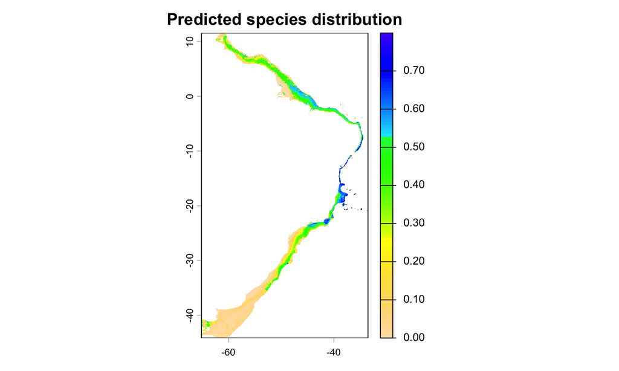

```r
# map the predicted distribution
plot(prediction$rasterLayer, main = "Predicted species distribution", col = rev(topo.colors(100)))
```

S5 // Developing Species Distribution Models in R

biodiversityDS .

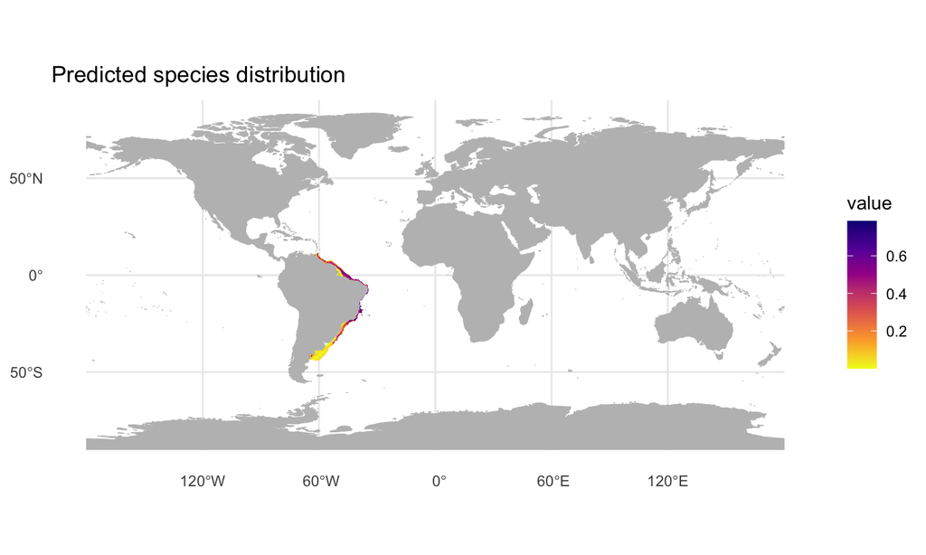

```r
# map the predicted distribution
ggplot() + geom_spatvector(data = landmass, fill = "gray", color = "gray") + geom_spatraster(data = prediction$rasterLayer) +
    labs(title = "Predicted species distribution") + scale_fill_viridis_c(option = "plasma",
    direction = -1, na.value = NA) + theme_minimal()
```

S5 // Developing Species Distribution Models in R

biodiversityDS .

### Presence / pseudo-absence data

If **true absence data is not available**, but one wants to fit a model, **pseudo-absence** data can be generated.

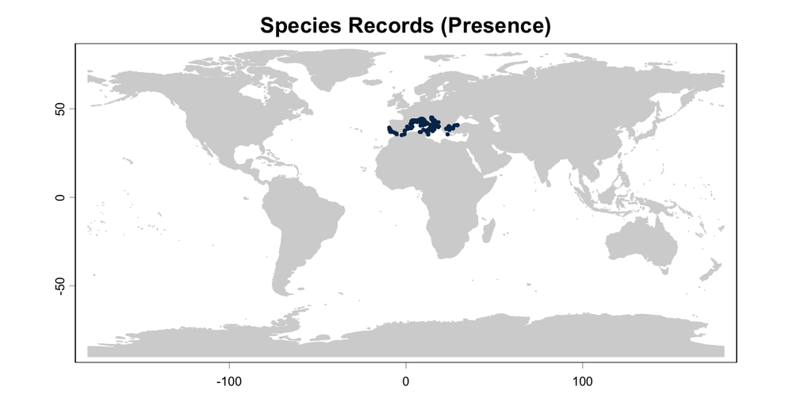

```r
# read occurrence records (presences)
presences <- read.table("../Data/Text delimited/species_presence_records.csv", sep = ";", header = TRUE)
# transform data.frame into a spatial object
presences <- vect(presences, geom = c("Lon", "Lat"), crs = "EPSG:4326")
# plot records
plot(landmass, main = "Species Records (Presence)", col = "#D4D4D4", border = "#D4D4D4", axes = TRUE)
plot(presences, col = "#043259", pch = 16, cex = 0.5, add = TRUE)
```

S5 // Developing Species Distribution Models in R

biodiversityDS .

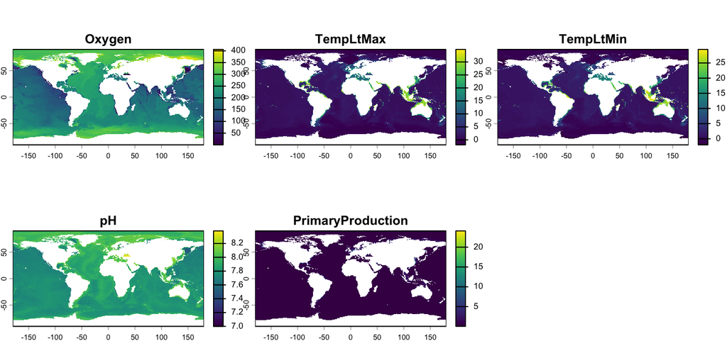

```r
# import environmental data
files <- c("../Data/Raster data/Present Benthic DissolvedMolecularOxygen Mean.tif", # Oxygen
           "../Data/Raster data/Present Benthic OceanTemperature LtMax.tif", # Temperatur Max
           "../Data/Raster data/Present Benthic OceanTemperature LtMin.tif", # Temperatur Min
           "../Data/Raster data/Present Benthic pH Mean.tif", # pH
           "../Data/Raster data/Present Benthic TotalPrimaryProductionPhyto Mean.tif" # Productivity
)
# produce and plot raster layers
environmentalLayers <- rast(files)
# change for friendly names
names(environmentalLayers) <- c("Oxygen","TempLtMax","TempLtMin","pH","PrimaryProduction")
plot(environmentalLayers)
```

S5 // Developing Species Distribution Models in R

biodiversityDS .

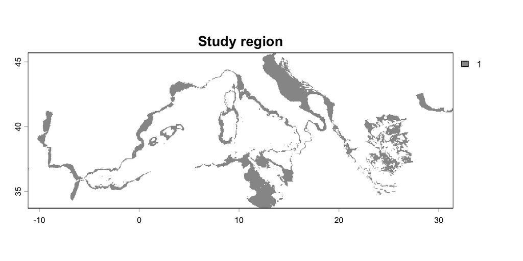

```r
# develop a study region layer
myStudyRegion <- studyRegion(rasterLayers=environmentalLayers, # SpatRaster of layers
                             presences=presences, # presence records
                             distanceThreshold=200000, # distance from records in meters
                             topographyLayer = "../Data/Raster data/Bathymetry.tif", # bathymetry layer
                             verticalPref=c(-15,-300)) # known vertical distribution

# inspect the study region layer
plot(myStudyRegion, main="Study region", col="#979797", axes=TRUE)
```

S5 // Developing Species Distribution Models in R

biodiversityDS .

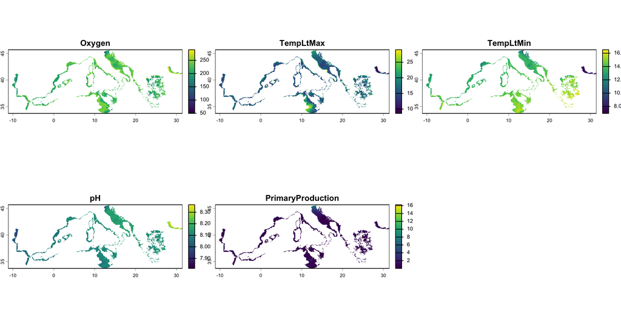

```r
# crop the environmental layers to the extent of the study region
environmentalLayers <- crop(environmentalLayers, myStudyRegion)
# mask the environmental layers with the study region
environmentalLayers <- mask(environmentalLayers, myStudyRegion)
# plot the masked environmental layers
plot(environmentalLayers, axes = TRUE)
```

S5 // Developing Species Distribution Models in R

biodiversityDS .

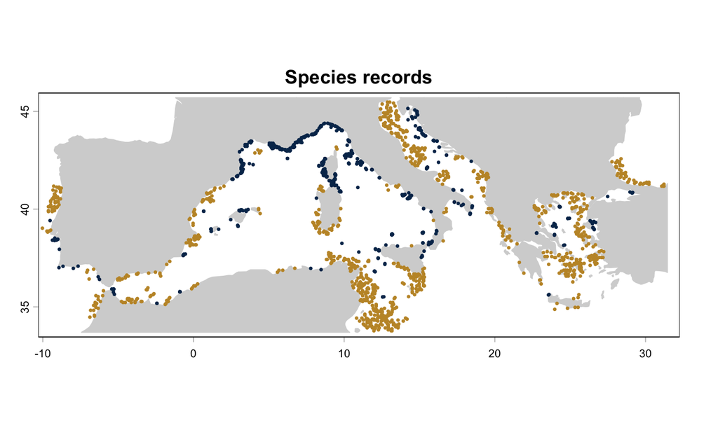

```r
# generate pseudo-absences
absences <- pseudoAbsences(rasterLayers = environmentalLayers, presences = presences, n = 1000)
# crop landmass to the region for better representation
landmassMed <- crop(landmass, myStudyRegion)
# plot records
plot(landmassMed, main = "Species records", col = "#D4D4D4", border = "#D4D4D4", axes = TRUE)
plot(absences, col = "#c29431", pch = 16, cex = 0.5, add = TRUE)
plot(presences, col = "#043259", pch = 16, cex = 0.5, add = TRUE)
```

S5 // Developing Species Distribution Models in R

biodiversityDS .

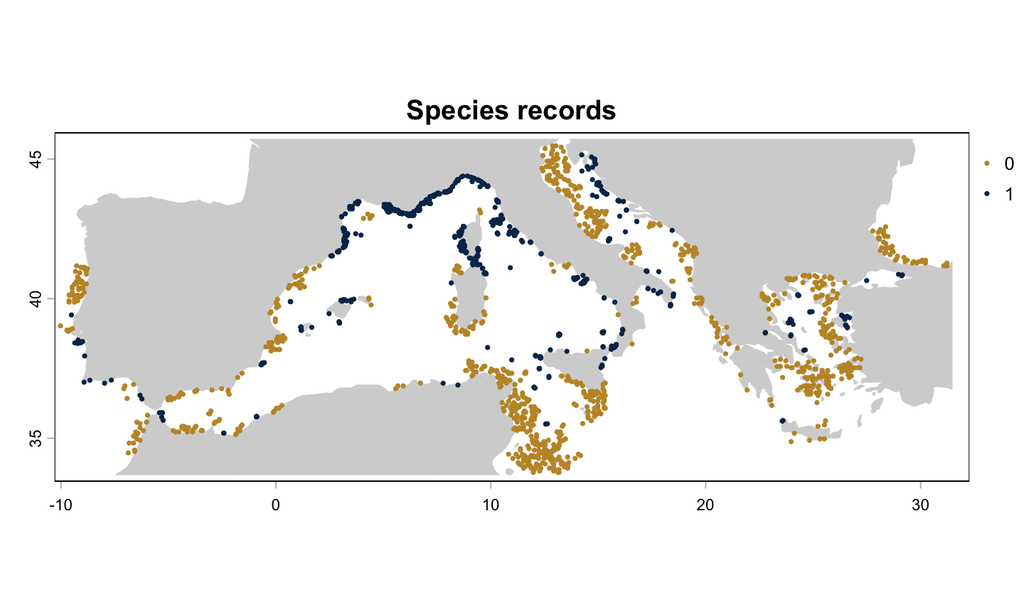

```r
# combine presences and absences into a unique object for modelling
presences$PA <- 1
absences$PA <- 0
records <- rbind(presences, absences)
# plot records
plot(landmassMed, main = "Species records", col = "#D4D4D4", border = "#D4D4D4", axes = TRUE)
plot(records, y = "PA", col = c("#c29431", "#043259"), pch = 16, cex = 0.5, add = TRUE)
```

S5 // Developing Species Distribution Models in R

biodiversityDS .

```r
# extract environmental values and make an object with all information to model.
modelData <- generateModelData(records, environmentalLayers = environmentalLayers, paMinimum = 100,
    bootstrapRounds = 10, paRatio = 1)
# fit a BRT model to the dataset
model <- trainModel(modelData, algorithm = "brt")
# predict the distribution with the model over a raster stack
prediction <- predictModel(model = model, newData = environmentalLayers)
```

S5 // Developing Species Distribution Models in R

biodiversityDS .

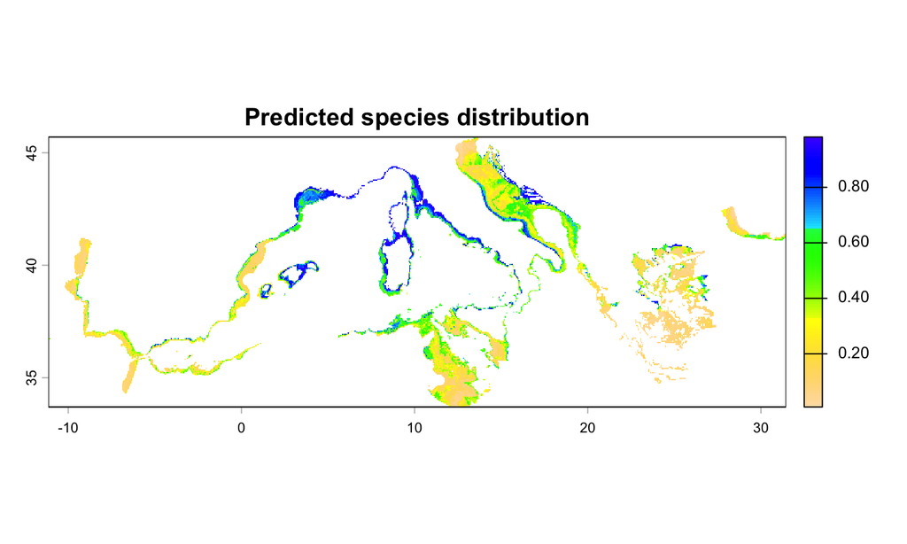

```r
# map the predicted distribution
plot(prediction$rasterLayer, main = "Predicted species distribution", col = rev(topo.colors(100)))
```

S5 // Developing Species Distribution Models in R

biodiversityDS .

### Presence / background data

If true absence data is not available, but one wants to **fit a Maxent model**, **background data** can be generated.

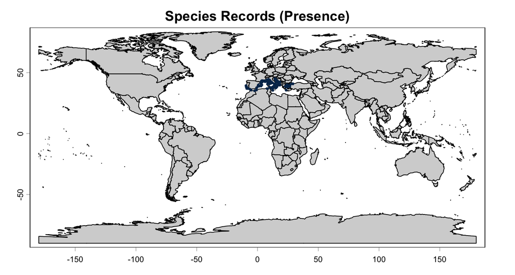

```r
# read occurrence records (presences) and transform to spatial object
presences <- read.table("../Data/Text delimited/species_presence_records.csv", sep = ";", header = TRUE)
presences <- vect(presences, geom = c("Lon", "Lat"), crs = "EPSG:4326")
# plot records
plot(landmass, main = "Species Records (Presence)", col = "#D4D4D4", axes = TRUE)
plot(presences, col = "#043259", pch = 16, cex = 0.5, add = TRUE)
```

S5 // Developing Species Distribution Models in R

biodiversityDS .

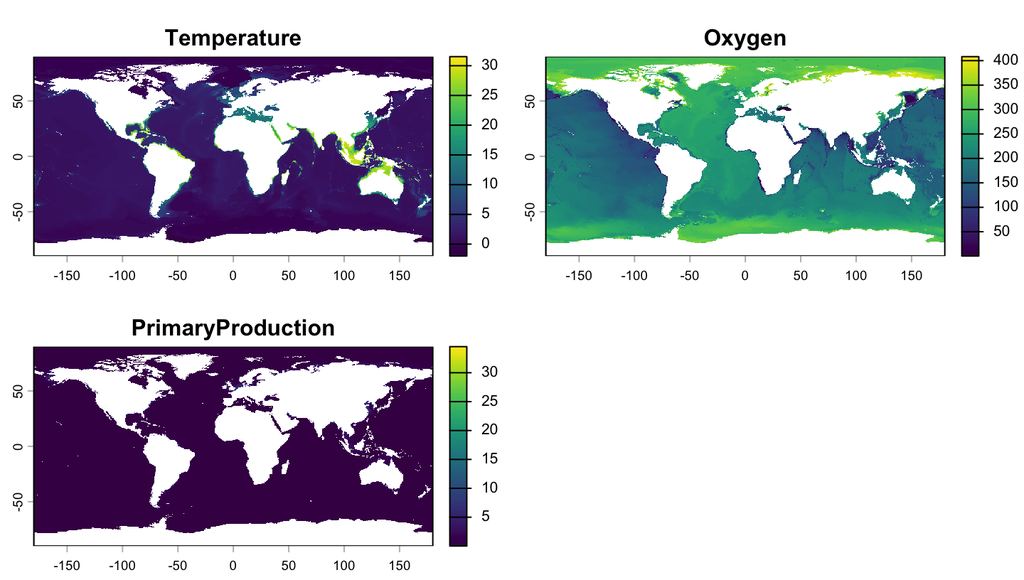

```r
# download layers for present conditions
variables <- list(var1 = c("thetao", "mean", "depthmean"), var2 = c("o2", "mean", "depthmean"),
    var3 = c("phyc", "mean", "depthmean"))
environmentalLayers <- download_multiple_layers(variables = variables, experiment = c("baseline"),
    decade = c(2010))
# change for friendly names
names(environmentalLayers) <- c("Temperature", "Oxygen", "PrimaryProduction")
# plot layers
plot(environmentalLayers, axes = TRUE)
```

S5 // Developing Species Distribution Models in R

biodiversityDS .

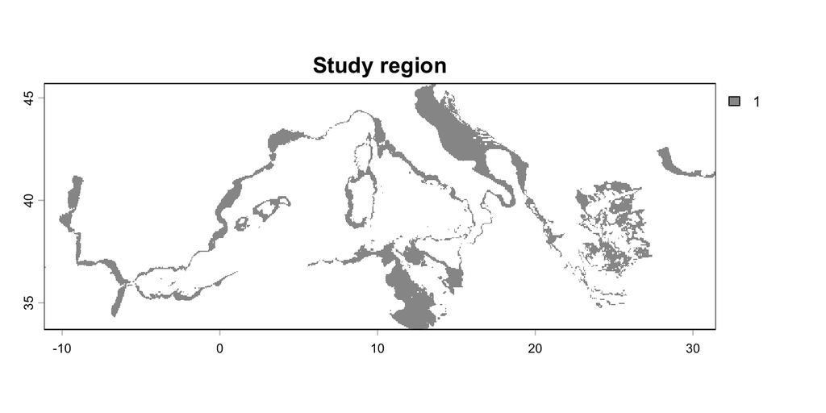

```r
# develop a study region layer
myStudyRegion <- studyRegion(rasterLayers=environmentalLayers, # SpatRaster of layers
                             presences=presences, # presence records
                             distanceThreshold=200000, # distance from records in meters
                             topographyLayer = "../Data/Raster data/Bathymetry.tif", # bathymetry layer
                             verticalPref=c(-15,-300)) # known vertical distribution

# inspect the study region layer
plot(myStudyRegion, main="Study region", col="#979797", axes=TRUE)
```

S5 // Developing Species Distribution Models in R

biodiversityDS .

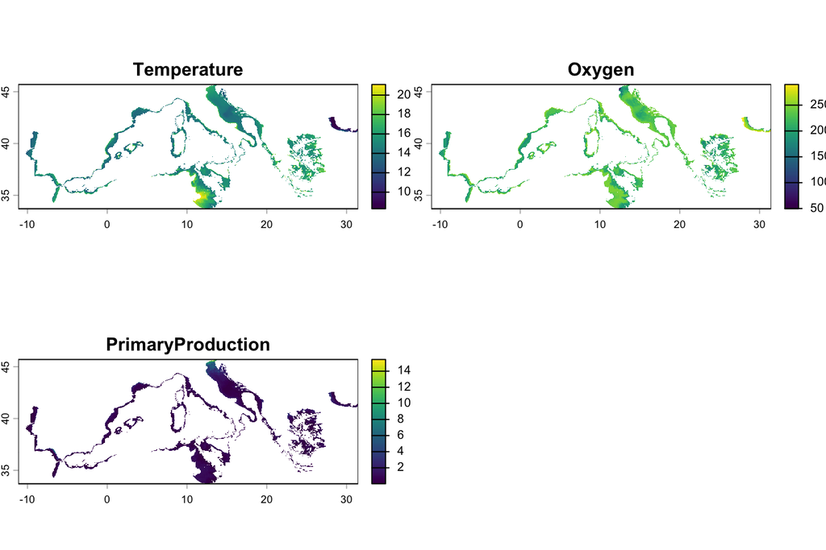

```r
# crop the environmental layers to the extent of the study region
environmentalLayers <- crop(environmentalLayers, myStudyRegion)
# mask the environmental layers with the study region
environmentalLayers <- mask(environmentalLayers, myStudyRegion)
# plot the masked environmental layers
plot(environmentalLayers, axes = TRUE)
```

S5 // Developing Species Distribution Models in R

biodiversityDS .

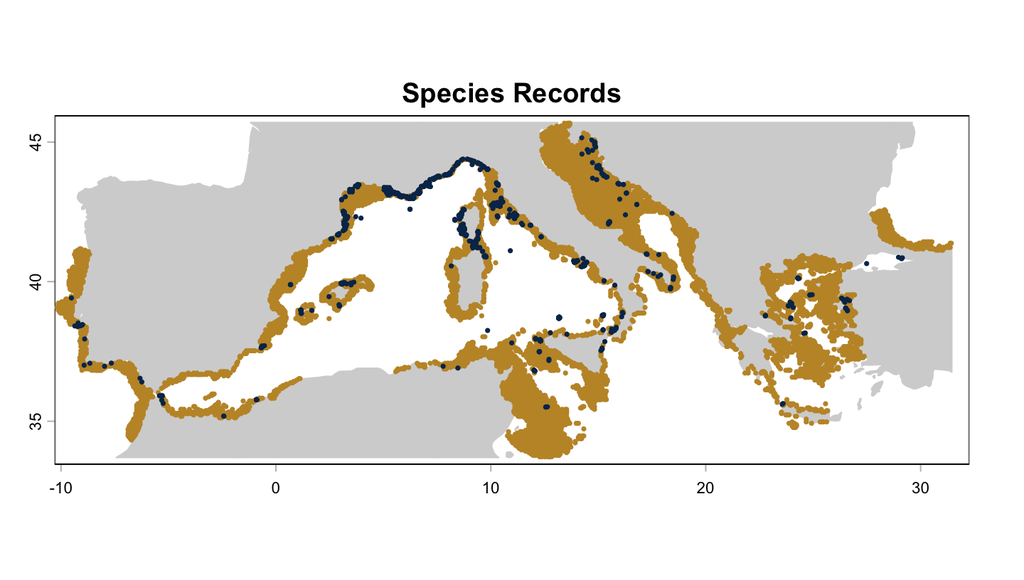

```r
# generate background data
background <- backgroundInformation(rasterLayers = environmentalLayers, n = 10000)
# crop landmass to the region for better representation
landmassMed <- crop(landmass, myStudyRegion)
# plot records
plot(landmassMed, main = "Species Records", col = "#D4D4D4", border = "#D4D4D4", axes = TRUE)
plot(background, col = "#c29431", pch = 16, cex = 0.5, add = TRUE)
plot(presences, col = "#043259", pch = 16, cex = 0.5, add = TRUE)
```

S5 // Developing Species Distribution Models in R

biodiversityDS .

```r
# combine presences and absences into a unique object for modelling
presences$PA <- 1
background$PA <- 0
records <- rbind(presences, background)
# extract environmental values and make an object with all information to model
modelData <- generateModelData(records, environmentalLayers, paMinimum = 10000, bootstrapRounds = 10)
# fit a maxent model to the dataset
model <- trainModel(modelData, algorithm = "maxent")
# predict the distribution with the model over a raster stack
prediction <- predictModel(model = model, newData = environmentalLayers)
```

biodiversityDS .

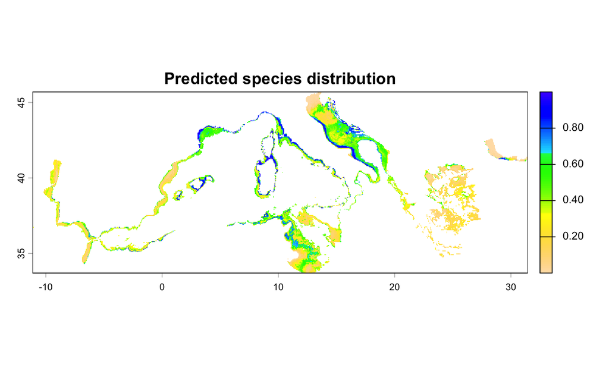

```r
# map the predicted distribution
plot(prediction$rasterLayer, main = "Predicted species distribution", col = rev(topo.colors(100)))
```

S5 // Developing Species Distribution Models in R

biodiversityDS .

### Challenge 5.1

The objective of this challenge is to **fit** a brt model to occurrence (presence / absence) and environmental data.

**Packages, data and functions to accomplish the challenge:**

**Files to use**  
"species_presence_absence_records.csv"  
"Present Benthic DissolvedMolecularOxygen Mean.tif"  
"Present Benthic OceanTemperature LtMax.tif”"  
"Present Benthic OceanTemperature LtMin.tif”"  
"Present Benthic pH Mean.tif”"  
"Present Benthic TotalPrimaryProductionPhyto Mean.tif"  
**Functions to use**  
library  
rast  
plot  
studyRegion  
crop  
mask  
generateModelData  
trainModel  
predictModel

S5 // Developing Species Distribution Models in R

biodiversityDS .

### Challenge 5.2

The objective of this challenge is to **fit** a brt model to occurrence (presence / pseudo-absence) and environmental data.

**Packages, data and functions to accomplish the challenge:**

**Files to use**  
"species_presence_records.csv"  
"Present Benthic DissolvedMolecularOxygen Mean.tif"  
"Present Benthic OceanTemperature LtMax.tif”"  
"Present Benthic OceanTemperature LtMin.tif”"  
"Present Benthic pH Mean.tif”"  
"Present Benthic TotalPrimaryProductionPhyto Mean.tif"  
**Functions to use**  
library  
rast  
plot  
studyRegion  
pseudoAbsences  
crop  
mask  
generateModelData  
trainModel  
predictModel

S5 // Developing Species Distribution Models in R

biodiversityDS .

### Challenge 5.3

The objective of this challenge is to **fit** a maxent model to occurrence (presence / background) and environmental data.

**Packages, data and functions to accomplish the challenge:**

**Files to use**  
"species_presence_records.csv"  
"Present Benthic DissolvedMolecularOxygen Mean.tif"  
"Present Benthic OceanTemperature LtMax.tif”"  
"Present Benthic OceanTemperature LtMin.tif”"  
"Present Benthic pH Mean.tif”"  
"Present Benthic TotalPrimaryProductionPhyto Mean.tif"  
**Functions to use**  
library  
rast  
plot  
studyRegion  
backgroundInformation  
crop  
mask  
generateModelData  
trainModel  
predictModel

S5 // Developing Species Distribution Models in R

## Temporal model transferability

biodiversityDS .

Model **transferability is the process of transferring a model to a new dataset**. **Temporal** transferability is the task of predicting **to a distinct time period** than where the model was trained.

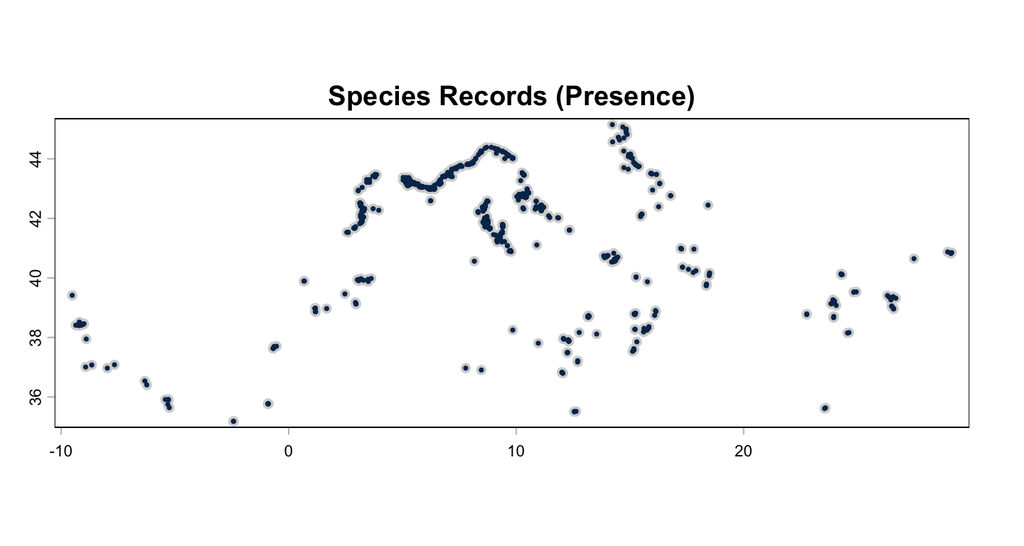

```r
# read occurrence records (presences) and transform to spatial object
presences <- read.table("../Data/Text delimited/species_presence_records.csv", sep = ";", header = TRUE)
presences <- vect(presences, geom = c("Lon", "Lat"), crs = "EPSG:4326")
# plot records
plot(presences, main = "Species Records (Presence)", col = "#D4D4D4", border = "#D4D4D4", axes = TRUE)
plot(presences, col = "#043259", pch = 16, cex = 0.5, add = TRUE)
```

S5 // Developing Species Distribution Models in R

biodiversityDS .

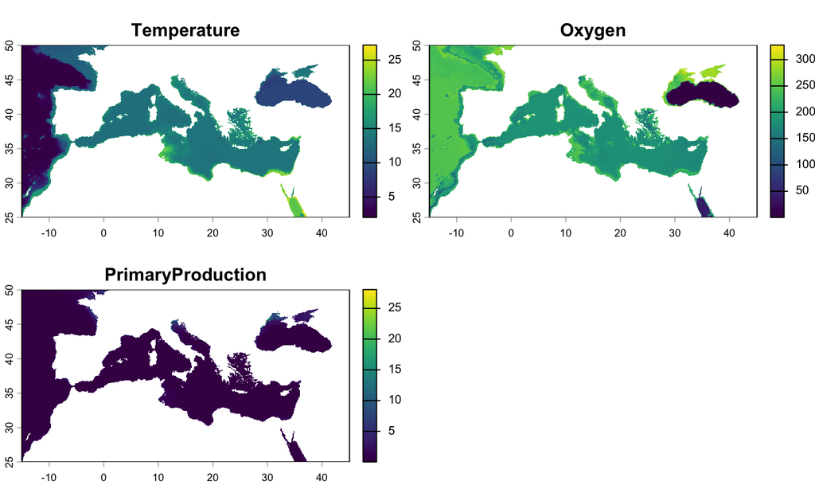

```r
# download layers for present conditions
variables <- list(var1 = c("thetao", "mean", "depthmean"), var2 = c("o2", "mean", "depthmean"),
    var3 = c("phyc", "mean", "depthmean"))
environmentalLayersPres <- download_multiple_layers(variables = variables, experiment = c("baseline"),
    decade = c(2010), longitude = c(-15, 45), latitude = c(25, 50))
# change for friendly names
names(environmentalLayersPres) <- c("Temperature", "Oxygen", "PrimaryProduction")
# plot layers
plot(environmentalLayersPres, axes = TRUE)
```

S5 // Developing Species Distribution Models in R

biodiversityDS .

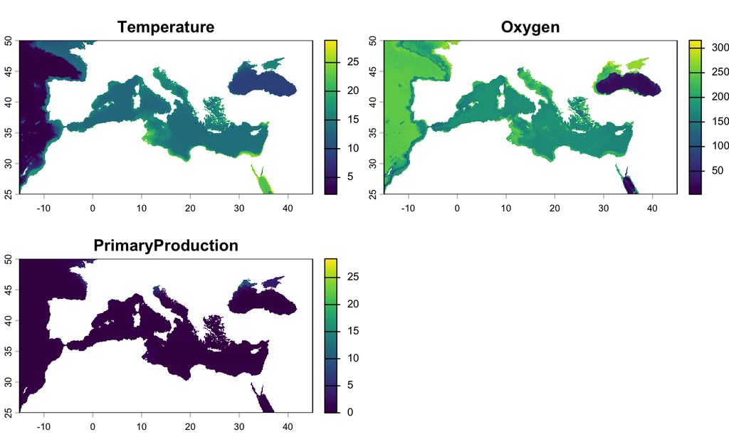

```r
# download layers for end-of-century conditions
environmentalLayersFut <- download_multiple_layers(variables = variables, experiment = c("ssp245"),
    decade = c(2090), longitude = c(-15, 45), latitude = c(25, 50))
# change for friendly names
names(environmentalLayersFut) <- c("Temperature", "Oxygen", "PrimaryProduction")
# plot layers
plot(environmentalLayersFut, axes = TRUE)
```

S5 // Developing Species Distribution Models in R

biodiversityDS .

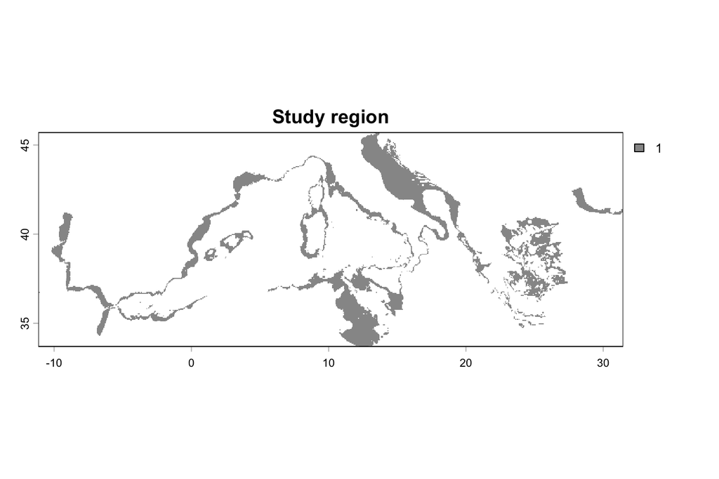

```r
# develop a study region layer
myStudyRegion <- studyRegion(rasterLayers=environmentalLayersPres, # SpatRaster of layers
                             presences=presences, # presence records
                             distanceThreshold=200000, # distance from records in meters
                             topographyLayer = "../Data/Raster data/Bathymetry.tif", # bathymetry layer
                             verticalPref=c(-15,-300)) # known vertical distribution

# inspect the study region layer
plot(myStudyRegion, main="Study region", col="#979797", axes=TRUE)
```

S5 // Developing Species Distribution Models in R

biodiversityDS .

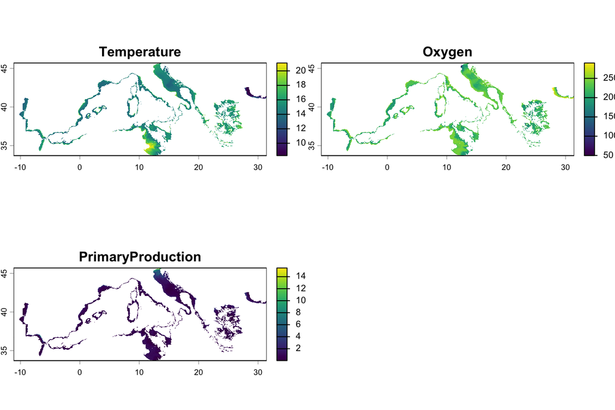

```r
# crop the environmental layers to the extent of the study region
environmentalLayersPres <- crop(environmentalLayersPres, myStudyRegion)
# mask the environmental layers with the study region
environmentalLayersPres <- mask(environmentalLayersPres, myStudyRegion)
# plot the masked environmental layers
plot(environmentalLayersPres, axes = TRUE)
```

S5 // Developing Species Distribution Models in R

biodiversityDS .

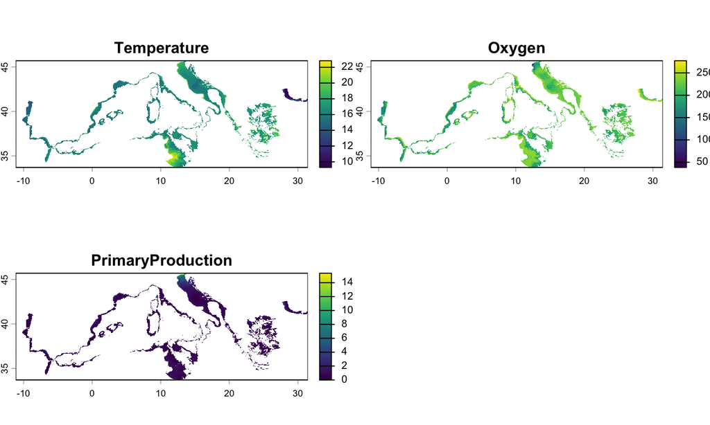

```r
# crop the environmental layers to the extent of the study region
environmentalLayersFut <- crop(environmentalLayersFut, myStudyRegion)
# mask the environmental layers with the study region
environmentalLayersFut <- mask(environmentalLayersFut, myStudyRegion)
# plot the masked environmental layers
plot(environmentalLayersFut, axes = TRUE)
```

S5 // Developing Species Distribution Models in R

biodiversityDS .

For proper transferability, the name of the layers must be the same in the two datasets.

```r
# inspect the names of the datasets
names(environmentalLayersPres)
```

```
## [1] "Temperature"       "Oxygen"            "PrimaryProduction"
```

```r
names(environmentalLayersFut)
```

```
## [1] "Temperature"       "Oxygen"            "PrimaryProduction"
```

```r
# test if names are the same
all.equal(names(environmentalLayersPres), names(environmentalLayersFut))
```

```
## [1] TRUE
```

S5 // Developing Species Distribution Models in R

biodiversityDS .

```r
# generate pseudo-absences
absences <- pseudoAbsences(rasterLayers = environmentalLayersPres, presences = presences, n = 1000)
# combine presences and absences into a unique object for modelling
presences$PA <- 1
absences$PA <- 0
records <- rbind(presences, absences)
# extract environmental values and make an object with all information to model
modelData <- generateModelData(records, environmentalLayers = environmentalLayersPres, bootstrapRounds = 10,
    paMinimum = 100, paRatio = 1)
# fit a BRT model to the dataset
model <- trainModel(modelData, algorithm = "brt")
```

S5 // Developing Species Distribution Models in R

biodiversityDS .

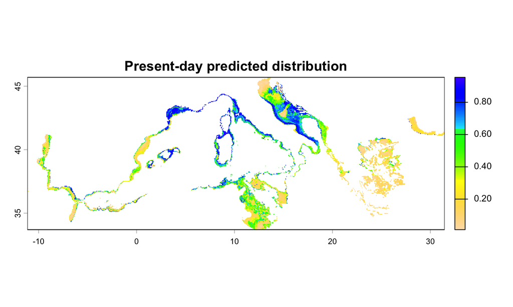

```r
# predict the distribution to the present-day conditions
predictionPres <- predictModel(model = model, newData = environmentalLayersPres)
# map the predicted distribution
plot(predictionPres$rasterLayer, main = "Present-day predicted distribution", col = rev(topo.colors(100)))
```

S5 // Developing Species Distribution Models in R

biodiversityDS .

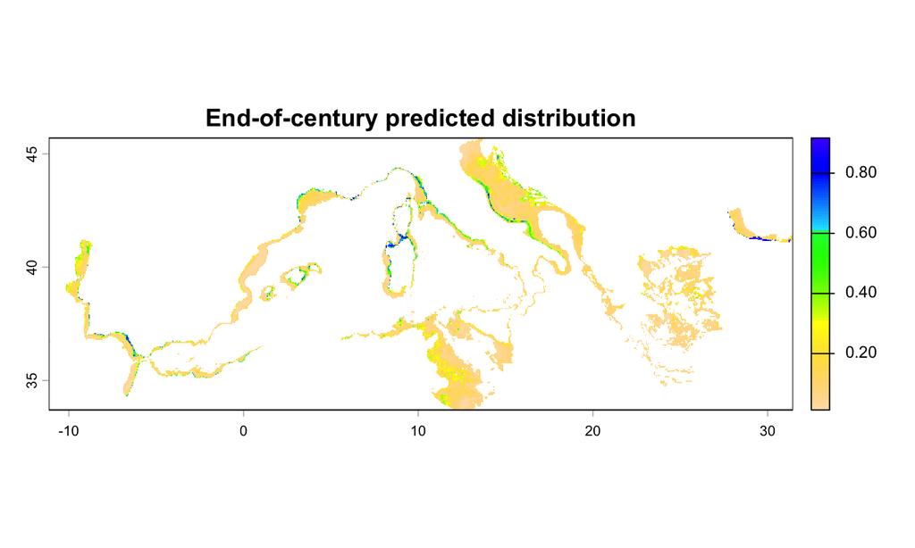

```r
# predict the distribution to the present-day conditions
predictionFut <- predictModel(model = model, newData = environmentalLayersFut)
# map the predicted distribution
plot(predictionFut$rasterLayer, main = "End-of-century predicted distribution", col = rev(topo.colors(100)))
```

S5 // Developing Species Distribution Models in R

biodiversityDS .

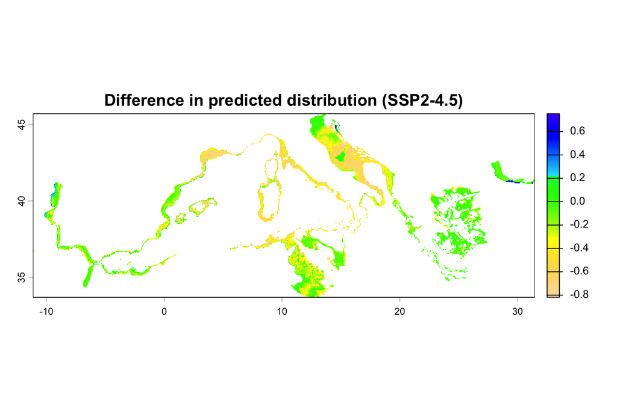

```r
# plot difference in predicted distribution
diffPrediction <- predictionFut$rasterLayer - predictionPres$rasterLayer
plot(diffPrediction, main = "Difference in predicted distribution (SSP2-4.5)", col = rev(topo.colors(100)))
```

S5 // Developing Species Distribution Models in R

biodiversityDS .

### Challenge 5.4

The main objective of this challenge is to **fit** a brt model to occurrence (presence / pseudo-absence) and environmental data and **transfer the model to a different period**.

**Packages, data and functions to accomplish the challenge:**

**Files to use**  
"species_presence_records.csv"  
**Functions to use**  
library  
download_multiple_layers  
rast  
plot  
studyRegion  
pseudoAbsences  
crop  
mask  
generateModelData  
trainModel  
predictModel

S5 // Developing Species Distribution Models in R

## Spatial model transferability

biodiversityDS .

Spatial transferability is the task of predicting a model to a distinct region than where the model was trained.

```r
# get data from OBIS and transform to spatial object
presences <- getExternalDataObis(taxa = "Undaria pinnatifida", getCitation = TRUE)
```

```r
# transform data.frame to spatial object
presences <- vect(presences, geom = c("Lon", "Lat"), crs = "EPSG:4326")
```

S5 // Developing Species Distribution Models in R

biodiversityDS .

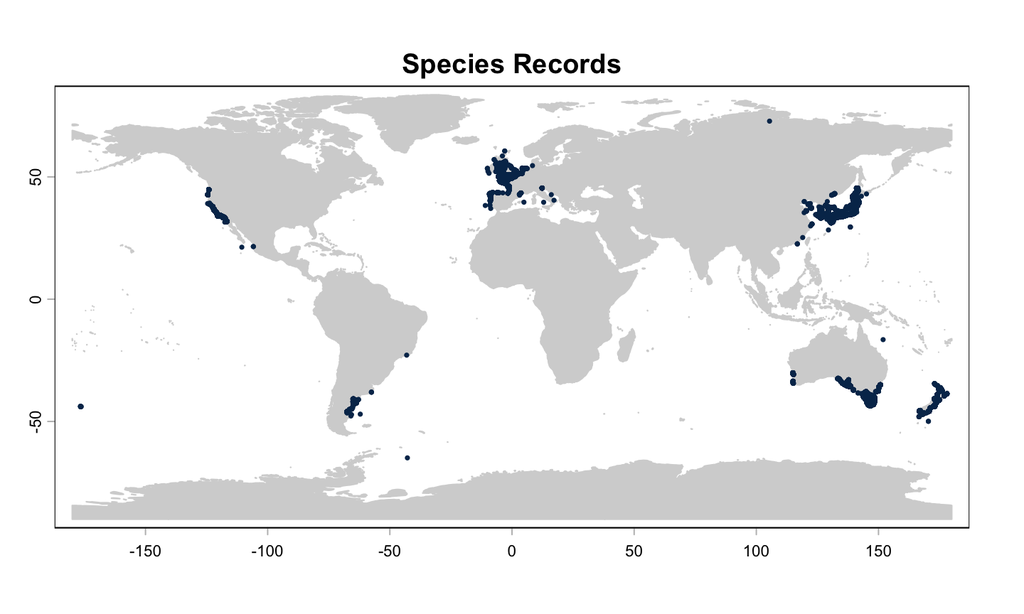

```r
# load a vector defining global landmasses
landmass <- vect("../Data/Vector data/Landmass/landmass.shp")
# plot records
plot(landmass, main = "Species Records", col = "#D4D4D4", border = "#D4D4D4", axes = TRUE)
plot(presences, col = "#043259", pch = 16, cex = 0.5, add = TRUE)
```

S5 // Developing Species Distribution Models in R

biodiversityDS .

```r
# download layers for the native range
variables <- list(var1 = c("thetao", "ltmax", "depthsurf"), var2 = c("thetao", "ltmin", "depthsurf"),
    var3 = c("no3", "ltmin", "depthsurf"))
environmentalLayersNative <- download_multiple_layers(variables = variables, experiment = c("baseline"),
    decade = c(2010), longitude = c(115, 155), latitude = c(20, 50))
# change for friendly names
names(environmentalLayersNative) <- c("TempLtMax", "TempLtMin", "Nutrients")
```

S5 // Developing Species Distribution Models in R

biodiversityDS .

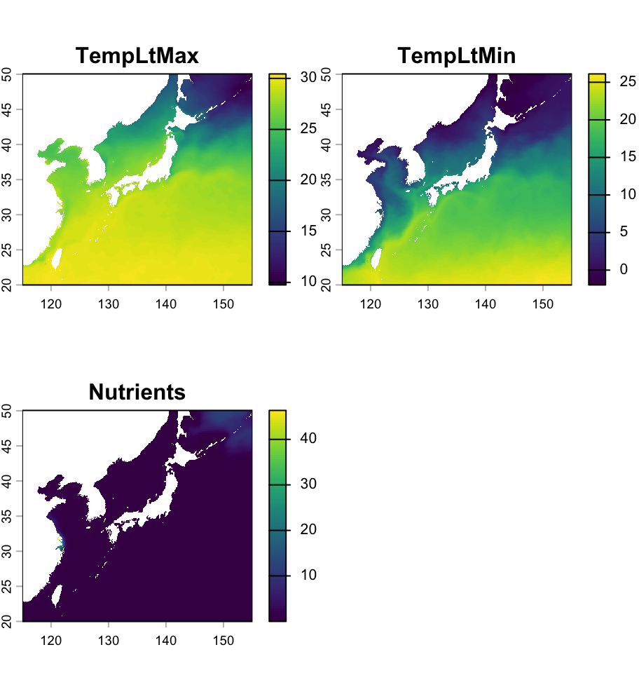

```r
# plot layers
plot(environmentalLayersNative, axes = TRUE)
```

S5 // Developing Species Distribution Models in R

biodiversityDS .

```r
# download layers for the non-native range
environmentalLayersInv <- download_multiple_layers(variables = variables, experiment = c("baseline"),
    decade = c(2010), longitude = c(-15, 40), latitude = c(25, 75))
# change for friendly names
names(environmentalLayersInv) <- c("TempLtMax", "TempLtMin", "Nutrients")
```

S5 // Developing Species Distribution Models in R

biodiversityDS .

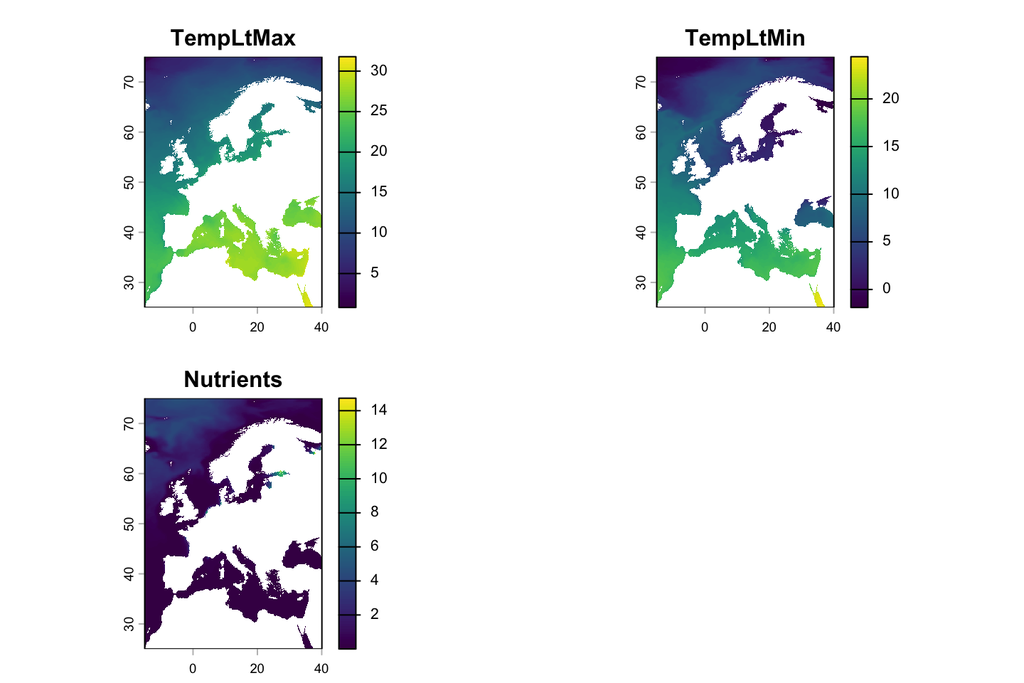

```r
# plot layers
plot(environmentalLayersInv, axes = TRUE)
```

S5 // Developing Species Distribution Models in R